# Evaluating the Best Fit Model for the Outcome in Car Seat Sales

Liz Walters

12/21/2018

## Introduction

For this assignment, I used the “Carseat” dataset from the text *“An Introduction to Satistical Learning”* to test what models express the best fit, from a supervised learning approach. The reason I chose to focus on linear models by a supervised learning approach is beacuse previous work I have done in data analysis and undergraduate work composed of linear regression models through statistical or econometric approaches, so I wanted to grasp linear model fits from a supervised learning stand point. Something that was discussed in class was that statiticians and econometricians are more interested in making inferences about a unique solution, but in data mining it is more of interest to make predictions for the already existent outcomes.

I use this supervised learning approach to analyze if variables in the “Carseat” dataset, which contains data for the sales of car seats in 400 different locations, are good model predictors of the outcome. To do so I split the dataset into training data, which is used to obtain the outcome b, and testing data, which is used to evaluate the model that predicts the outcome. In this supervised learning approach I want to see how well the the different variables in the “Carseat” dataset express predictive ability. To do so, after splitting the data into training and testing data, I will display the data by ggplot visualization to see the variations in variables, and then I will compare models for best fit by which has the lowest root mean squared error (RMSE).

## Data

```r
#Open the ISLR Package

library(ISLR)

#Upload the "Careseats" data from the ISLR package

data("Carseats")
```

The dependent variable is:

*Sales* - Unit sales (in thousands) at each location

The predictors are:

*CompPrice* - Price charged by competitor at each location

*Income* - Community income level (in thousands of dollars)

*Advertising* - Local advertising budget for company at each location (in thousands of dollars)

*Population* - Population size in region (in thousands)

*Price* - Price company charges for car seats at each site

*ShelveLoc* - A factor with levels Bad, Good and Medium indicating the quality of the shelving location for the car seats at each site

*Age* - Average age of the local population

*Education* - Education level at each location

*Urban* - A factor with levels No and Yes to indicate whether the store is in an urban or rural location

*US* - A factor with levels No and Yes to indicate whether the store is in the US or not

```r
#Split the data into training and testing

library(caret)
set.seed(12345)
in_train <- createDataPartition(y = Carseats$Sales, p = 3 / 4, list = FALSE)
training <- Carseats[in_train, ]
testing <- Carseats[-in_train, ]
```

## Visualization (ggplot)

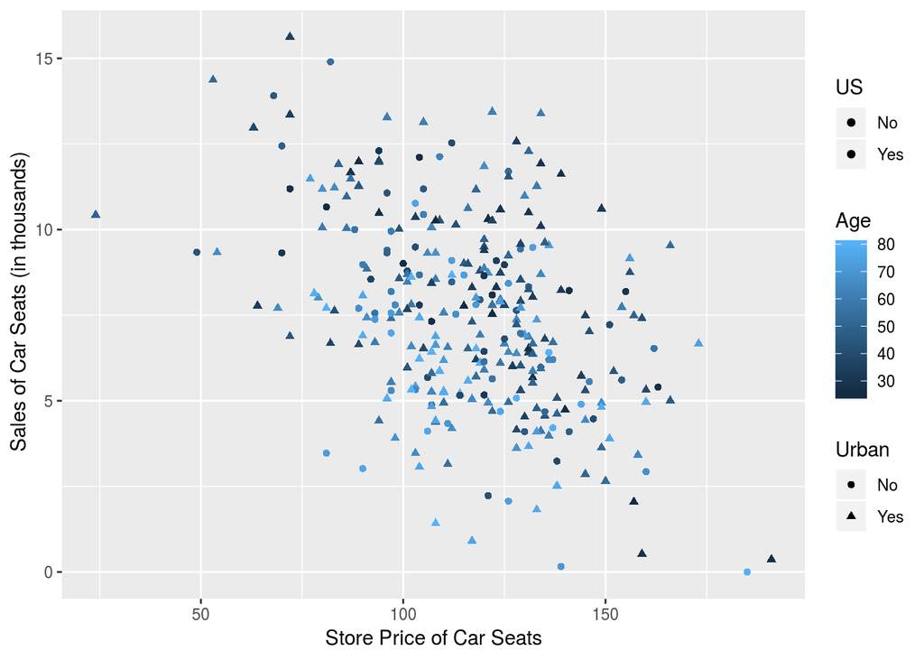

```r
#Visualize the data using ggplot to show possible variations in predictors on the dependent variable

library(ggplot2)
ggplot(training) +
  geom_point(aes(x = Price, y = Sales,
                 col = Age, shape = Urban,
                 fill = US)) +
  xlab("Store Price of Car Seats") + ylab(" Sales of Car Seats (in thousands)")
```

This plot shows a bit of variation in the data, but it also shows that the data has a trend directed downward and negatively correlated. So as prices of the carseats increase at the store locations, the sales of the carseats decrease. This would make sense with assumptions and outcomes.This plot depicts the assumption that the *Price* variable may be a good predictor for sales.